# Results

Author

Wenlin Ye

Published

May 1, 2023

# 1 Non-technical report

## 1.1 Background & Initial questions

This thrombosis analysis with regard to collagen diseases was based on dataset that consists of medical records for patients at a University hospital outpatient clinic specializing in collagen diseases. The data is divided into three tables that can be connected using patient ID numbers. All they contain are basic patient information and diagnosis details, the information on examination dates, lab results, and thrombosis occurrences, and a comprehensive list of laboratory test results. The main goals of this study are to identify patterns for detecting and predicting thrombosis, find temporal patterns related to thrombosis and collagen diseases, and classify collagen diseases accurately.

1.How does the sex of patients with collagen diseases impact their laboratory test results, and are there any differences in the test results or disease severity between male and female patients?

2.Are there any patterns in laboratory test results or symptom onset (specific collagen disease subtypes e.g., C3 C4) that are specific to certain collagen diseases, and can these patterns be used to improve the accuracy of disease classification?

3.Are there any Special laboratory test results (e.g., ANA, aCL IgG, or aCL IgM) that show a strong correlation with the occurrence of thrombosis in these patients?

## 1.2 Plot 1 regarding first question

First, we deal with questios about how the sex of patients with collagen diseases impact their laboratory test results, and if there any differences in the test results or disease severity between male and female patients.

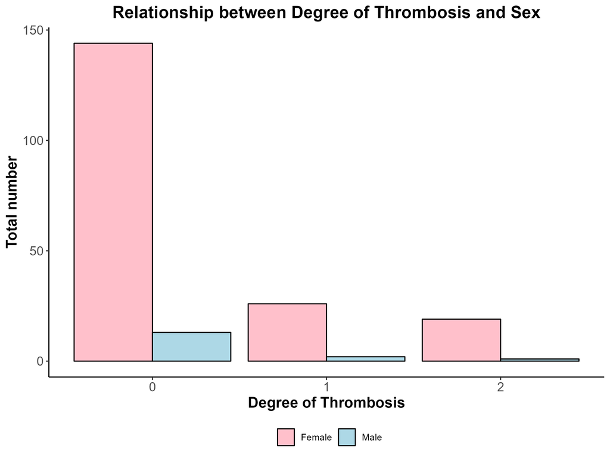

Figure 1 Relationship between Degrees of Thrombosis and Sex

## 1.3 Plot 2 regarding second question

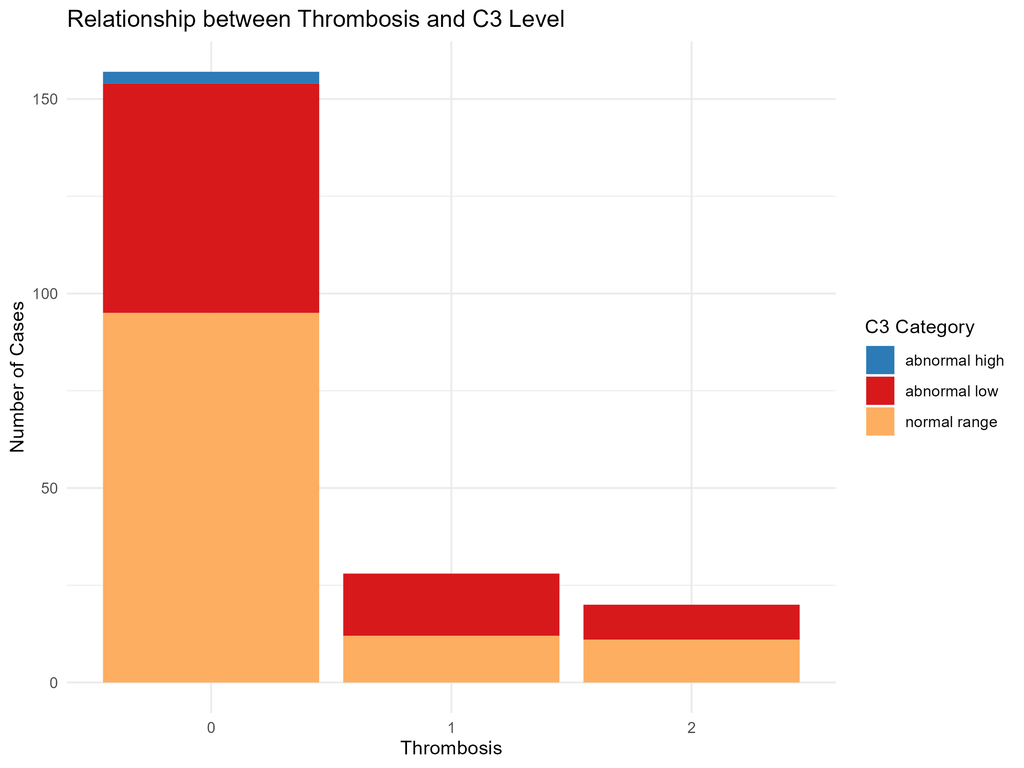

Figure 2 Relationship between Degrees of Thrombosis and C3 level

The stacked bar plot indicates that the proportion of abnormal low C3 levels was higher in patients with thrombosis than those without thrombosis. Patients without thrombosis had relatively large amounts of C3 level in normal range, while about half of the positive and even severe thrombosis patients had abnormal low levels of C3. This indicates that C3 lab test results are likely to be correlated with the degree of thrombosis.

In general, this visualization highlights the importance of monitoring C3 levels in patients with collagen diseases, especially in those with thrombosis. It suggests that patients with low C3 levels may be at a higher risk for developing thrombosis and may need closer caring and potentially precaution strategies. However, it is worth noting that the number of patients with abnormal high C3 levels was relatively small in our dataset, so further investigation is needed.

## 1.4 Plot 3 regarding third question

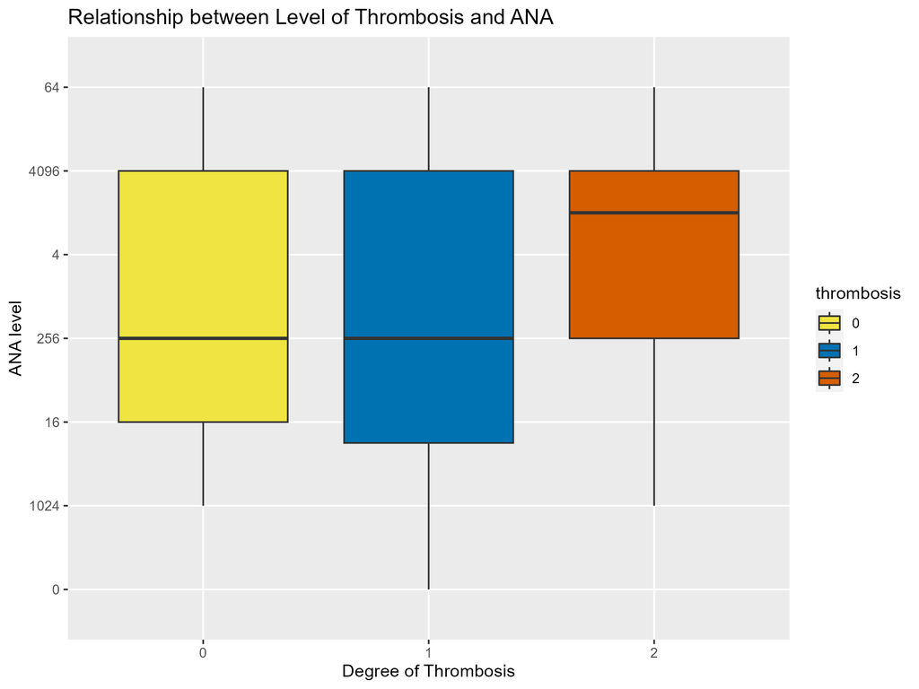

Figure 3 Relationship between Level of Thrombosis and ANA